# Análisis espacial de puntos

# 1 Carga de datos y paquetes

Los datos con los que trabajaremos consisten en dos bases de datos. Cada base de datos contiene las coordenadas medidas en el eje de abscisas y el de ordenadas para una serie de puntos. Las observaciones de *Q. ilex* son corresponden a *rebrotes* (reproducción asexual), mientras las observaciones de *Q. faginea* corresponden a *plántula* (reproducción sexual).

# 2 Análisis univariante

```r
# 3. Análisis univariante
# 3.1. Definir función de análisis univariante
analisis_univariante <- function(lista, n = 999) {
  # Normalización de los nombre
  nombres <- tolower(gsub("[[:punct:]]", "_", names(lista)))
  names(lista) <- nombres

  # Lista de guardado
  resultados <- list()

  # Bucle de análisis univariante
  for(i in nombres) {
    # Carga de los datos de la especie
    df <- lista[[i]]

    # Construcción del objeto 'ppp'
    x <- ppp(df$x, df$y, window = owin(range(df$x), range(df$y)))

    # Guardado directo de los resultados en la lista
    resultados[[i]] <- list(
      K = envelope(x, Kest, nsim = n, correction = "all", verbose = FALSE),
      L = envelope(x, Lest, nsim = n, correction = "all", verbose = FALSE),
      Lc = envelope(x, center_Lest, nsim = n, correction = "all", verbose = FALSE),
      G = envelope(x, pcf, nsim = n, correction = "all", verbose = FALSE),
      O = envelope(x, Oest, nsim = n, correction = "all", verbose = FALSE)
    )
  }

  # Devuelve la lista de resultados
  return(resultados)
}

# 3.2. Cálculo de resultados
resultados_univariante <- analisis_univariante(lista = lista_dfs)

# 3.3. Visualización
# 3.3.1. Creamos la lista donde guardar los gráficos creados
graficos_univariante <- list()

# 3.3.2. Empleo de 'onpoint::plot_quantums()' para la visualización
for(i in names(resultados_univariante)) {
  # Lista de estadísticos para la especie
  estadisticos <- resultados_univariante[[i]]

  # Inicializar sublista para la especie
  graficos_univariante[[i]] <- list()

  # Iteramos sobre cada estadístico
  for(j in names(estadisticos)) {
    # Estadístico
    estadistico <- estadisticos[[j]]

    # Contruimos el gráfico
    p <- plot_quantums(
      input = estadistico,
      labels = c("observed < low", "low < observed < high", "observed > high"),
      line_size = 0.8,
      base_size = 15,
      xlab = "r (metros)",
      ylab = j
    ) +
      labs(title = paste("Especie:", i , "| Estadístico:", j))

    # Guardamos en la lista
    graficos_univariante[[i]][[j]] <- p
  }
}
```

Tanto en el análisis univariante como en el bivariante vamos a emplear distintos estadísticos. Algunos dan los mismos resultados, pero tras otros subyacen lógicas y planteamientos diferentes, por lo que los resultados serán distintos. De este modo podremos comparar los resultados obtenidos y, (quizás) de este modo, logremos obtener conclusiones más robustas.

En este caso, todos los estadísticos y pruebas empleadas para el análisis espacial corresponderán a los tipos de métodos basados en las distancias físicas entre los puntos (o *nearest-neighbour methods*). A pesar de las diferencias en el modo de plantear el análisis espacial, todos se prueban contra la hipótesis nula ($H_0$) de que la distribución de los puntos es aleatoria. En concreto, se testa contra una *distribución uniforme de Poisson*.

En concreto, en el análisis espacial univariante, emplearemos:

## 2.1 Función K de Ripley $(K(r))$ univariante

Este estadístico parametriza el tipo, intensidad y rango de un patrón espacial concreto. Esta función es acumulativa, por lo que la información que revela a una determinada distancia corresponde al recuento de todos los puntos que se encuentran dentro del “disco” (que en la ecuación se denomina $A$, es decir, su área).

Su formulación es:

$$K \left( r \right) = n^{-2} A \sum_{i = 1}^n \sum_{j = 1}^n w_{ij}^{-1} I_{ij} \left( r \right)$$

siendo $w_{ij}^{-1}$ el factor de pesado, $n$ el número de puntos, e $I_{ij} \left( r \right)$:

$$I_{ij}(r) = \left[ \begin{array}{ll}
1 & \text{si } d_{ij} \leq r \\
0 & \text{si } d_{ij} > r
\end{array} \right.$$

Esta prueba la podemos ejecutar mediante la función `spatstat::Kest()`, y para nuestros datos el resultado fue:

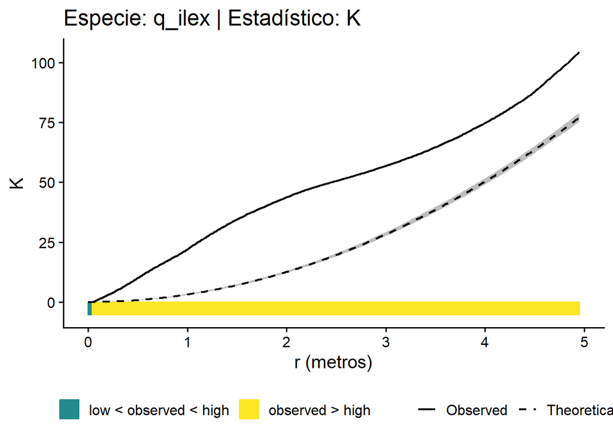

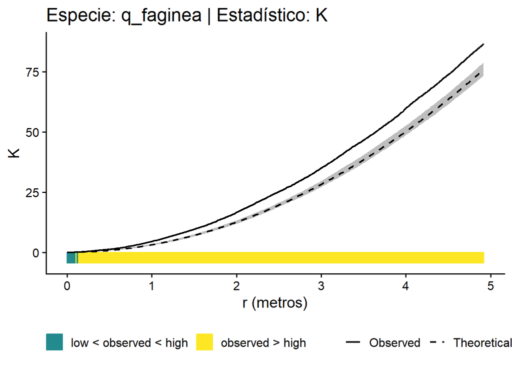

## 2.2 Transformación de la K de Ripley de Besag $(L(r))$ univariante

Para una distribución completamente aleatoria (*distribución uniforme de Poisson*) en el patrón de puntos, el valor teórico de la función sería $L(r) = r$. La raíz cuadrada estabiliza la varianza del estimador, por lo que es más idóneo para el contraste de hipótesis.

Su ecuación es:

$$L(r) = \sqrt{\frac{K(r)}{\pi}}$$

Esta prueba la podemos ejecutar mediante la función `spatstat::Lest()`, y para nuestros datos el resultado fue:

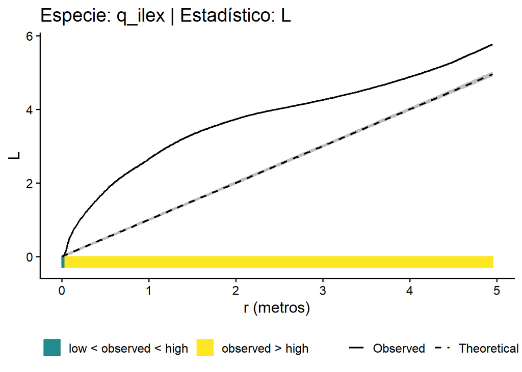

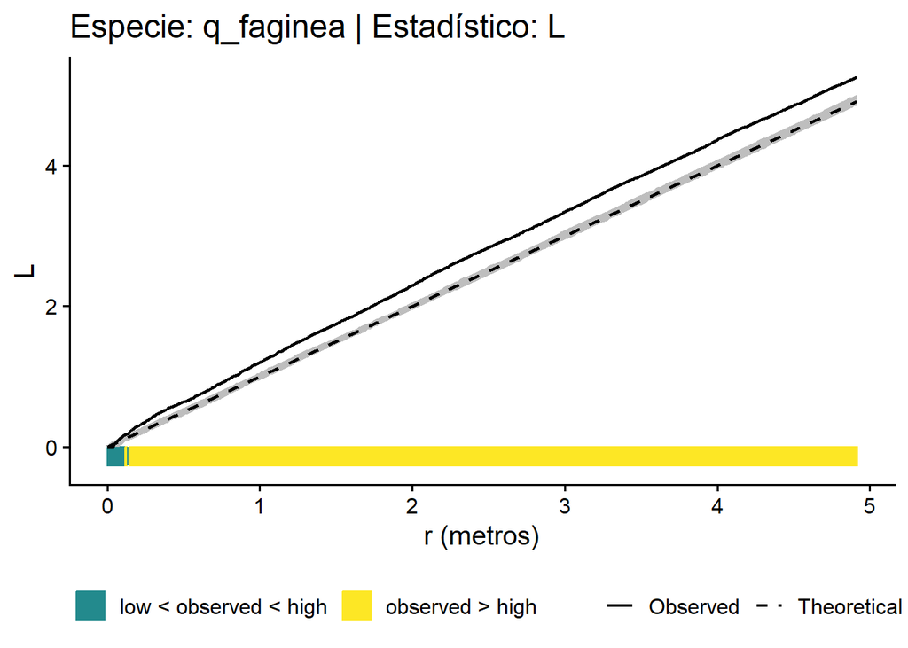

## 2.3 Transformación de la K de Ripley de Besag centrada $(L_c(r))$ univariante

Esta versión de la función permite una interpretación visual más clara y directa al centrar su valor en torno a 0.

Esta prueba la podemos ejecutar mediante la función `onpoint::center_Lest()`, y para nuestros datos el resultado fue:

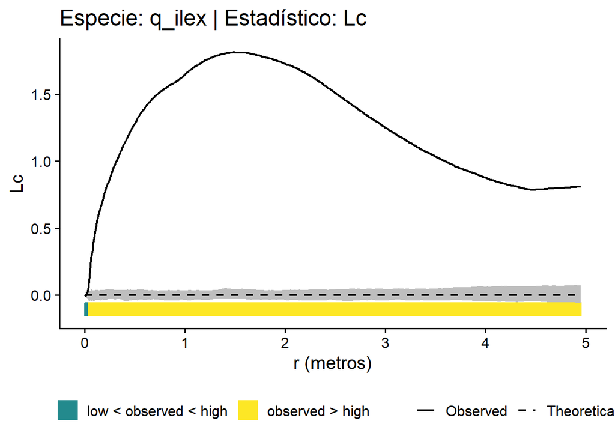

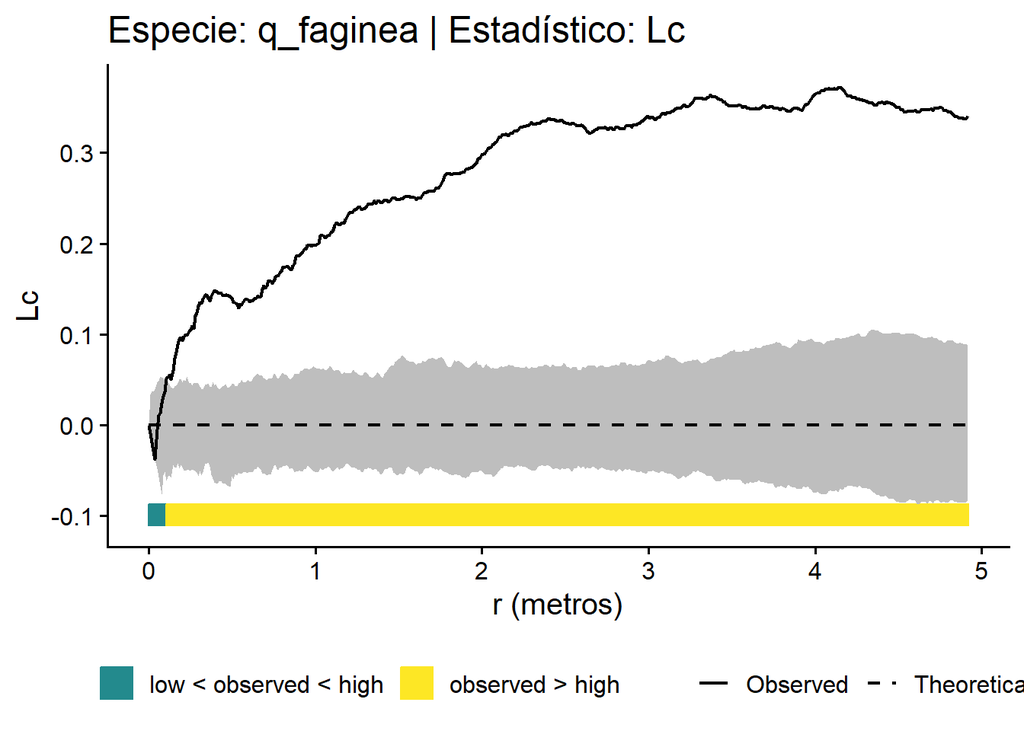

La interpretación del estadístico $Lc(r)$ es clara y directa para ambas especies. El patrón de distribución de *Q. ilex* es agregado, tanto a pequeña como a gran esscala espacial. Sin embargo, el patrón de agregación es más marcado a relativamente poca distancia (de $1-2 \ m$). Esto concuerda con nuestro conocimiento previo, pues se tratan de individuos reproducidos asexualmente. Además, podríamos hipotetizar como las encinas adultas ejercen un efecto *facilitador* sobre los individuos jóvenes reproducidos asexualmente, por lo que estos tenderían a agregarse entorno a los adultos.

## 2.4 Función de correlación por pares $(g(r))$ univariante

Se formula como:

$$g(r) = \frac{K'(r)}{2 \pi r}$$

siendo $K'(r)$ la derivada de $K(r)$. Para un proceso aleatorio de Poisson (distribución aleatoria de los datos), $g(r) = 1$. Valores de $g(r) \lt 1$ sugieren inhibición entre los puntos, mientras que valores de $g(r) \gt 1$ sugieren agregación.

Esta prueba la podemos ejecutar mediante la función `spatstat::pcf()`, y para nuestros datos el resultado fue:

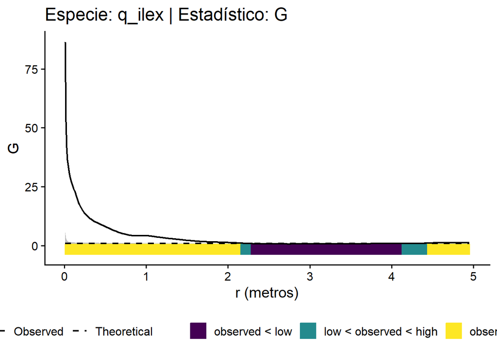

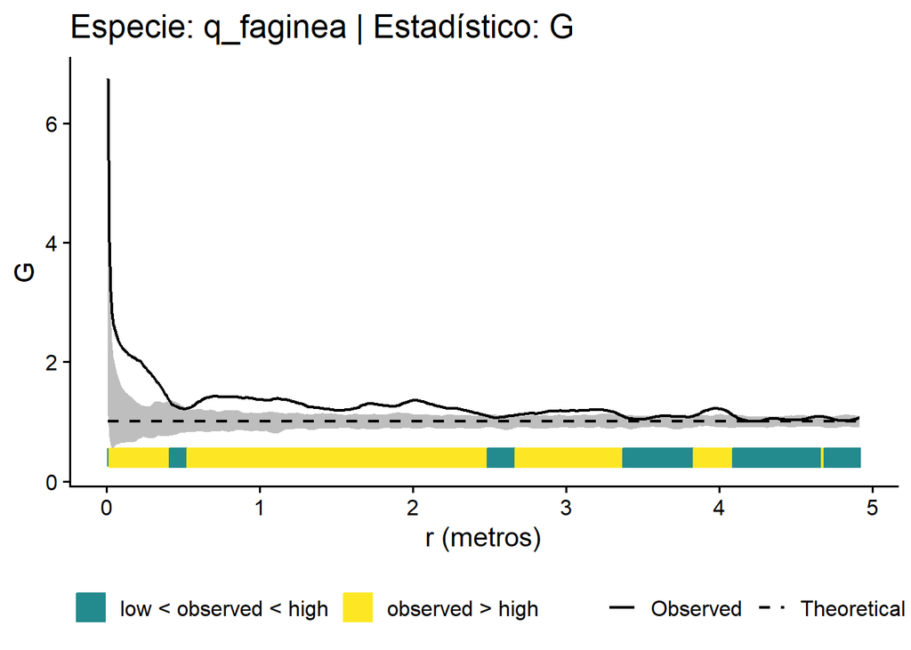

## 2.5 Estadístico O-ring $(O(r))$ univariante

Hablando de forma general, la función $(O(r))$ (Wiegand and A. Moloney 2004) escala la función $(g(r))$ gracias a la ayuda de la intensidad.

Esta prueba la podemos ejecutar mediante la función `onpoint::Oest()`, y para nuestros datos el resultado fue:

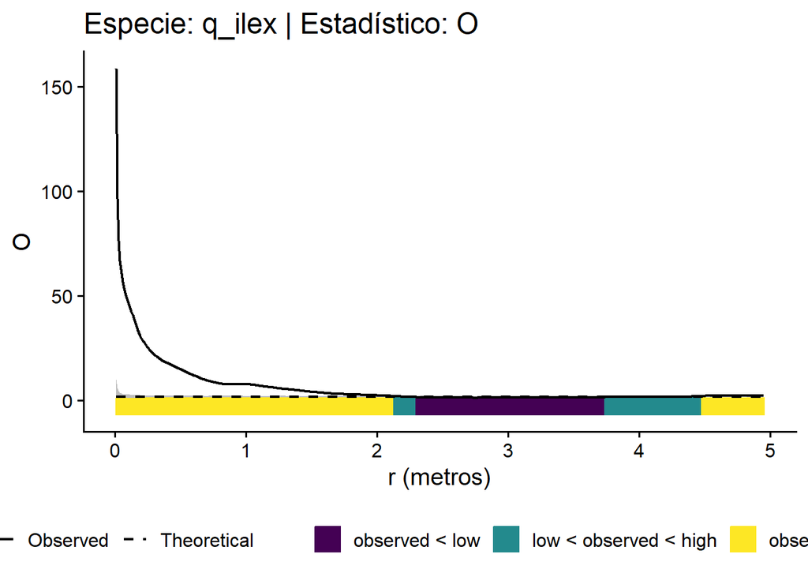

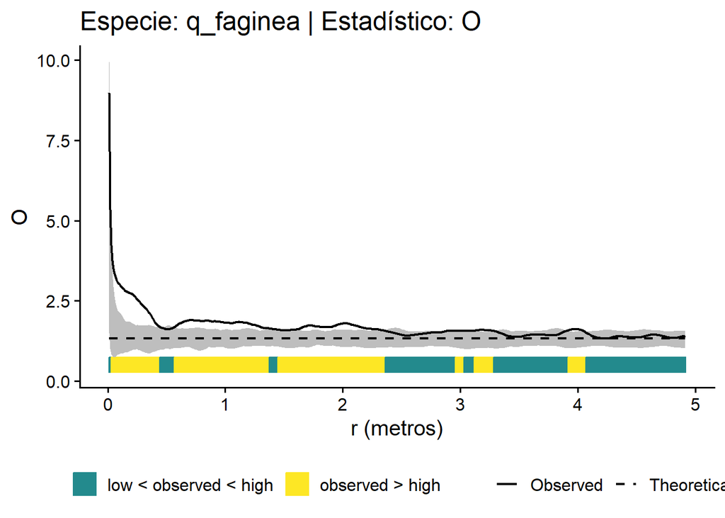

# 3 Análisis bivariante

```r
# 4. Análisis bivariante
# 4.1. Creamos la función de análisis bivariante
analisis_bivariante <- function(i, j, n = 999) {
  # Creación del objeto 'ppp'
  x <- ppp(
    x = c(i$x, j$x),
    y = c(i$y, j$y),
    window = owin(range(c(i$x, j$x)), range(c(i$y, j$y))),
    marks = factor(c(rep("1", nrow(i)), rep("2", nrow(j))))
  )

  # Cálculo de los estadísticos (combinación lineal de Eij y Eji)
  resultados <- list(
    K12 = envelope(x, Kcross, correction = "all", i = "1", j = "2", nsim = n, verbose = FALSE),
    L12 = envelope(x, Lcross, correction = "all", i = "1", j = "2", nsim = n, verbose = FALSE),
    G12 = envelope(x, pcfcross, correction = "all", i = "1", j = "2", nsim = n, verbose = FALSE)
  )
}

# 4.2. Cálculo de resultados
resultados_bivariante <- analisis_bivariante(i = lista_dfs$Q_ilex, j = lista_dfs$Q_faginea)

# 4.3. Visualización
# 4.3.1. Creamos la lista donde guardar los gráficos creados
graficos_bivariante <- list()

# 4.3.2. Empleo de 'onpoint::plot_quantums()' para la visualización
for(i in names(resultados_bivariante)) {
  # Lista de estadísticos para la especie
  estadistico <- resultados_bivariante[[i]]

  # Contruimos el gráfico
  p <- plot_quantums(
    input = estadistico,
    labels = c("observed < low", "low < observed < high", "observed > high"),
    line_size = 0.8,
    base_size = 15,
    xlab = "r (metros)",
    ylab = i
  ) +
    labs(title = paste("Estadístico:", i))

  # Guardamos en la lista
  graficos_bivariante[[i]] <- p
}
```

El paquete `spatstat` calcula por defecto la combinación lineal de los estadísticos de ambos análisis bivariables

## 3.1 Función K de Ripley $(K(r)_{12})$ bivariante

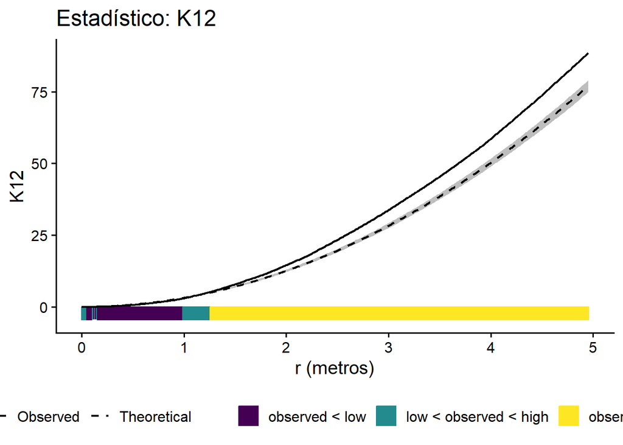

## 3.2 Transformación de la K de Ripley de Besag $(L(r)_{12})$ bivariante

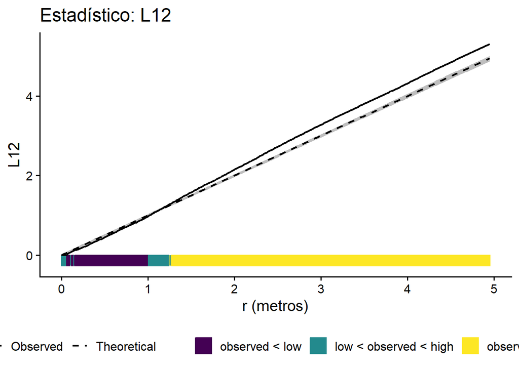

## 3.3 Función de correlación por pares $(g(r)_{12})$ bivariante

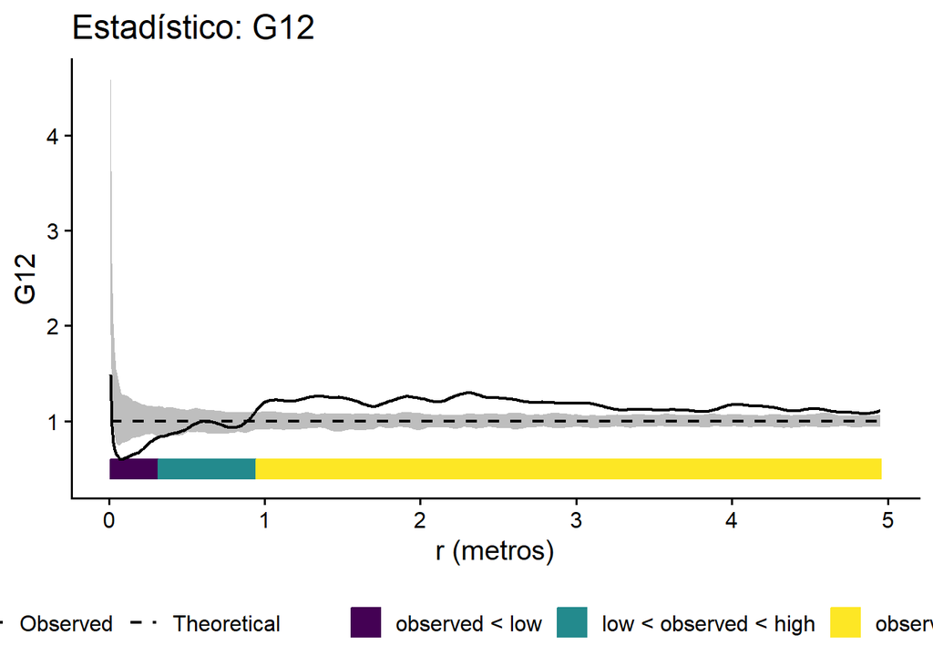

En el caso del análisis bivariantes, los resultados son más consistentes entre distintos estadísticos.

Se puede apreciar como existe un patrón mixto de segregación espacial a muy pequeña escala ($\lt 1 \ m$) y agregación a mediana-gran escala. La segregación posiblemente este marcada por la fuerte competencia interespecífica entre los juveniles de ambas especies. Por el contrario, la agregación a media distancia sugiere que ambos juveniles pueden compartir nicho, por lo que tienden a agruparse en áreas con los mismos recursos.

Por tanto, los datos sugieren la existencia de una competencia fuerte a cortas distancias (exclusión del micrositio), pero una coexistencia a nivel de rodal.

## References

Wiegand, Thorsten, and Kirk A. Moloney. 2004. “Rings, Circles, and Null-Models for Point Pattern Analysis in Ecology.” *Oikos* 104 (2): 209–29. https://doi.org/10.1111/j.0030-1299.2004.12497.x.